# homework 3

1. Use the full data set to perform the model with Class as a dependent variable. Use the stepAIC() function to obtain the best model based on AIC criteria. Use the backward selection procedure. Do not show the output.

```r
model_full<-glm(class~.,data=Bio_final, family = "binomial")
summary(model_full)
```

```
##
## Call:
## glm(formula = class ~ ., family = "binomial", data = Bio_final)
##
## Deviance Residuals:
##      Min        1Q    Median        3Q       Max
## -1.77975  -0.05362   0.00000   0.00002   2.78965
##
## Coefficients:
##               Estimate Std. Error z value Pr(>|z|)
## (Intercept)  4.179e+01  1.651e+01   2.532 0.011356 *
## age         -4.346e-02  2.766e-02  -1.571 0.116104
## bp           9.306e-02  4.791e-02   1.942 0.052086 .
## su.L         2.819e+00  3.152e+00   0.894 0.371090
## su.Q         2.314e+00  5.016e+00   0.461 0.644498
## su.C        -5.645e-01  3.733e+00  -0.151 0.879789
## su^4         9.688e-01  4.248e+00   0.228 0.819582
## su^5        -4.477e-01  6.344e+00  -0.071 0.943739
## rbcnormal   -4.853e+00  1.506e+00  -3.223 0.001267 **
## bapresent   -9.179e-01  1.272e+00  -0.721 0.470622
## bgr          4.108e-02  1.760e-02   2.334 0.019600 *
## sod         -1.658e-01  1.221e-01  -1.358 0.174507
## pot          1.913e-01  4.129e-01   0.463 0.643091
## hemo        -1.681e+00  4.424e-01  -3.799 0.000145 ***
## wbcc         3.999e-04  2.705e-04   1.478 0.139399
## rbcc        -1.325e+00  1.143e+00  -1.160 0.246182
## htnyes       2.006e+01  1.675e+03   0.012 0.990445
## dmyes        1.691e+00  1.653e+00   1.023 0.306463
## cadyes      -5.497e+00  2.283e+00  -2.408 0.016033 *
## appetpoor    4.636e-01  9.811e-01   0.473 0.636563
## aneyes      -1.856e-01  3.168e+00  -0.059 0.953273
## ---
## Signif. codes:  0 '***' 0.001 '**' 0.01 '*' 0.05 '.' 0.1 ' ' 1
##
## (Dispersion parameter for binomial family taken to be 1)
##
##     Null deviance: 440.356  on 321  degrees of freedom
## Residual deviance:  49.366  on 301  degrees of freedom
## AIC: 91.366
##
## Number of Fisher Scoring iterations: 20
```

```r
summary(model_step)
```

```
##
## Call:
## glm(formula = class ~ age + bp + rbc + bgr + hemo + rbcc + htn +
##     cad, family = "binomial", data = Bio_final)
##
## Deviance Residuals:
##      Min        1Q    Median        3Q       Max
## -1.90602  -0.04205   0.00000   0.00003   2.96198
##
## Coefficients:
##               Estimate Std. Error z value Pr(>|z|)
## (Intercept)   28.92773    7.39267   3.913 9.11e-05 ***
## age           -0.06148    0.02508  -2.451 0.014231 *
## bp             0.08240    0.04225   1.950 0.051141 .
## rbcnormal     -5.13429    1.40433  -3.656 0.000256 ***
## bgr            0.05760    0.01367   4.213 2.52e-05 ***
## hemo          -1.93304    0.42164  -4.585 4.55e-06 ***
## rbcc          -1.94837    0.89069  -2.187 0.028708 *
## htnyes        21.09955 1700.38908   0.012 0.990100
## cadyes        -5.63840    2.13268  -2.644 0.008198 **
## ---
## Signif. codes:  0 '***' 0.001 '**' 0.01 '*' 0.05 '.' 0.1 ' ' 1
##
## (Dispersion parameter for binomial family taken to be 1)
##
##     Null deviance: 440.356  on 321  degrees of freedom
## Residual deviance:  55.581  on 313  degrees of freedom
## AIC: 73.581
##
## Number of Fisher Scoring iterations: 20
```

2. Remove all non-significant variables from the last model. Show only the best model(all variables must be significant at least at the level 0.01). Use the summary() function to print the result.

```r
model_final<-glm(class ~rbc + bgr + hemo,data=Bio_final,family = 'binomial')
summary(model_final)
```

```
##
## Call:
## glm(formula = class ~ rbc + bgr + hemo, family = "binomial",
##     data = Bio_final)
##
## Deviance Residuals:
##      Min        1Q    Median        3Q       Max
## -3.04446  -0.13753   0.00051   0.05026   2.45960
##
## Coefficients:
##              Estimate Std. Error z value Pr(>|z|)
## (Intercept) 24.199549   4.087032   5.921 3.20e-09 ***
## rbcnormal   -3.758434   0.847104  -4.437 9.13e-06 ***
## bgr          0.043263   0.009165   4.720 2.36e-06 ***
## hemo        -1.970961   0.299331  -6.585 4.56e-11 ***
## ---
## Signif. codes:  0 '***' 0.001 '**' 0.01 '*' 0.05 '.' 0.1 ' ' 1
##
## (Dispersion parameter for binomial family taken to be 1)
##
##     Null deviance: 440.356  on 321  degrees of freedom
## Residual deviance:  97.913  on 318  degrees of freedom
## AIC: 105.91
##
## Number of Fisher Scoring iterations: 8
```

3. Pick your own new observation and predict the y value. Comment on it.

```r
predict(model_final,newdata = data.frame(rbc='normal',bgr=mean(Bio_final$bgr),hemo=mean(Bio_final$hemo),wbcc=mean(Bio_final$wbcc),htn='yes',ba="present"),type = 'response')
```

```
##       1
## 0.84106
```

4. Is it possible to calculate R square for logistic regression?

For logistic regression we use McFadden’s pseudo-R squared .

R2McFadden=1-log(Lc)/log(Lnull)

```r
intercept_only_model <- glm(class~1,data = Bio_final, family="binomial")
R2_McFadden<-1-logLik(model_final)/logLik(intercept_only_model)
R2_McFadden
```

```
## 'log Lik.' 0.7776502 (df=4)
```

**Problem 5. 7 pt.**

1. Divide the data frame into Train and Test sets (70:30), such that the proportion for training and testing sets must refer to the proportion of whole data. Do not forget about the set.seed() function.

```r
library(caret)
set.seed(1)
train_index<-createDataPartition(Bio_final$class, p = 0.7,list = F)

train<-Bio_final[train_index,]
test<-Bio_final[-train_index,]
```

```r
table(train$class)/sum(table(train$class))
```

```
##
## No ch. kidney disease  chronic kidney disease
##              0.4317181              0.5682819
```

```r
table(test$class)/sum(table(test$class))
```

```
##
## No ch. kidney disease  chronic kidney disease
##              0.4315789              0.5684211
```

2. Now fit two logistic regression models using training data. Both models should be the result of Problem 4a. and Problem 4b.

```r
model_for_final<-glm(model_final$formula,data = train,family = 'binomial')
model_for_step<-glm(model_step$formula,data = train,family = 'binomial')
```

3. For the first model (which contains only significant coefficients) predict the probability of the presence of chronic kidney disease for testing set. Compute the confusion matrix using table() function. Figure out the overall fraction of correct predictions, sensitivity, and specificity for the held out data using only confusion matrix. Check your computations using the function confusionMatrix().

```r
pred_for_final<-predict(model_for_final,newdata = test,type = 'response')

pr_class<-ifelse(pred_for_final>0.5,1,0)


conf_m<-addmargins(table(test$class,pr_class))
conf_m
```

```
##                         pr_class
##                           0  1 Sum
##   No ch. kidney disease  39  2  41
##   chronic kidney disease  4 50  54
##   Sum                    43 52  95
```

```r
overall_accur<-sum(c(conf_m[1,1],conf_m[2,2]))/conf_m[3,3]
overall_accur
```

```
## [1] 0.9368421
```

```r
sensitivity<-50/54
sensitivity
```

```
## [1] 0.9259259
```

```r
specificity<-39/41
specificity
```

```
## [1] 0.9512195
```

```r
#confusionMatrix(as.factor(pr_class),test$class,positive = "1")
```

4. Explain what the confusion matrix is telling you about the types of mistakes made by logistic regression.

   It is giving us info about type 1 (false positive: when we claim to have something when acctually we don’t have) and type 2 errors (false negative: when we reject to have something, when actually we have it)
5. What is the difference between the ROC and the precision-recall curve (PRC)? When do we need to consider PRC? Why? Plot the PRC if it is applicable to your models?

ROC curves should be used when the number of observations are equal for each class. Precision-Recall curves can be used when data is inbalanced. As ROC curves is applicable for datasets with imbalanced classes, when the proportion of positive to negative instances changes in a test set, the ROC curves stays the same.

6. Plot ROC curve for both models using the function ggroc {pROC}. Which models is the best? Why?

   According to ROC curves we can state that both models are acceptable , as for both cases the AUC is more than the benchmark (0.5).But the AUC for AIC model is bigger , so it is better.

```r
library(ROCR)
```

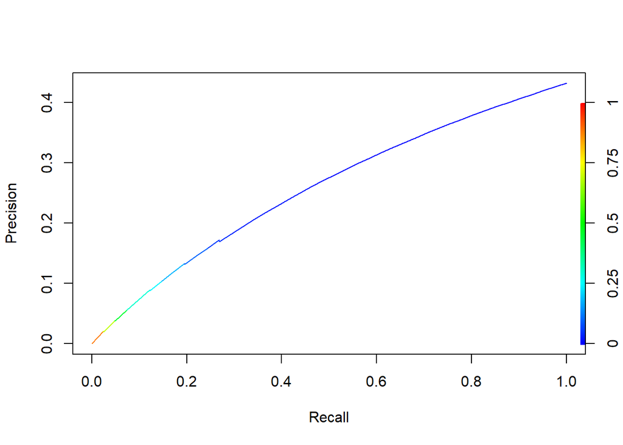

```r
p_test<-prediction(pred_for_final,test$class)
perf<-performance(p_test,"prec","rec")
plot(perf,colorize=T)
```

```r
library(pROC)
```

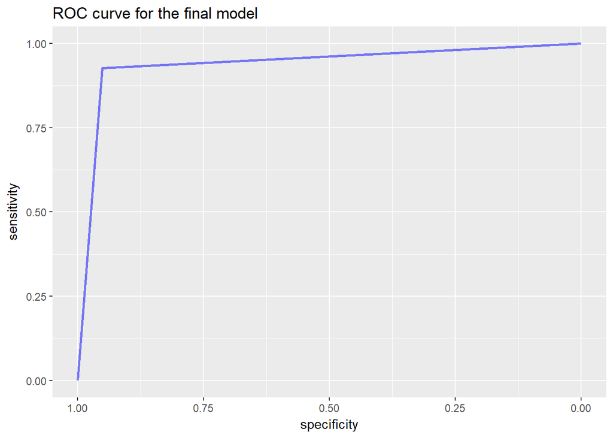

```r
roc<-roc(test$class,pr_class)
ggroc(roc,alpha = 0.5, colour = "blue", linetype = 1, size = 1)+ggtitle("ROC curve for the final model")
```

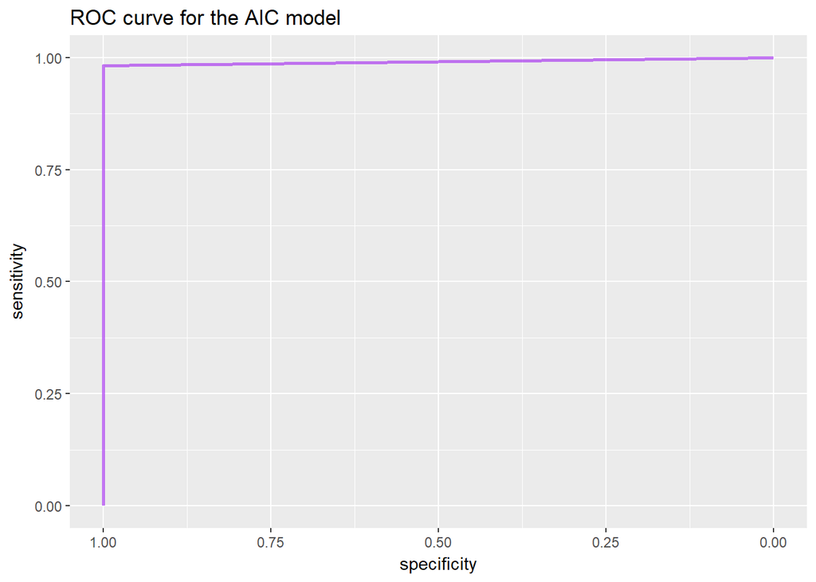

```r
pred1<-predict(model_step,newdata = test,type = 'response')
pr_class1<-ifelse(pred1>0.5,1,0)
roc1<-roc(test$class,pr_class1)
ggroc(roc1,alpha = 0.6, colour = "purple", linetype = 1, size = 1)+ggtitle("ROC curve for the AIC model ")
```

**Bonus. 2 pt**

While evaluating the goodness of fit of the first model I used the Hosmer-Lemeshow test. The Chi-square value of 9.156 is displayed on my output. Try to calculate this number without any extra libraries. Do not use the same functions which are written in Hosmer-Lemeshow test in R. **Hint:** Firstly you should understand the meaning of this test. I leave the first part of my code to obtain the same result and to help you solve the problem.

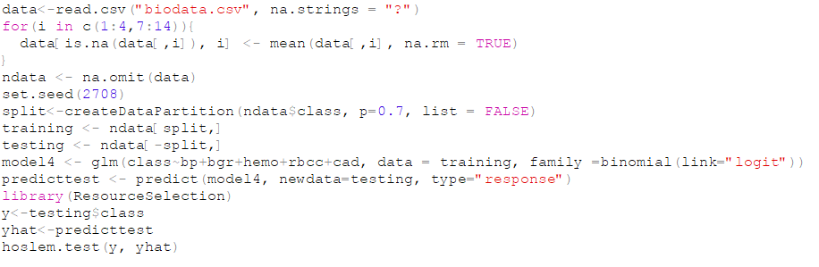

**Please, make brief and meaningful conclusions.**